# xgboost feature importance

Extracting and plotting feature importance

2018-12-01

This post will go over extracting feature (variable) importance and creating a function for creating a ggplot object for it. I will draw on the simplicity of Chris Albon’s post. For steps to do the following in Python, I recommend his [post](https://chrisalbon.com/machine_learning/trees_and_forests/feature_importance/).

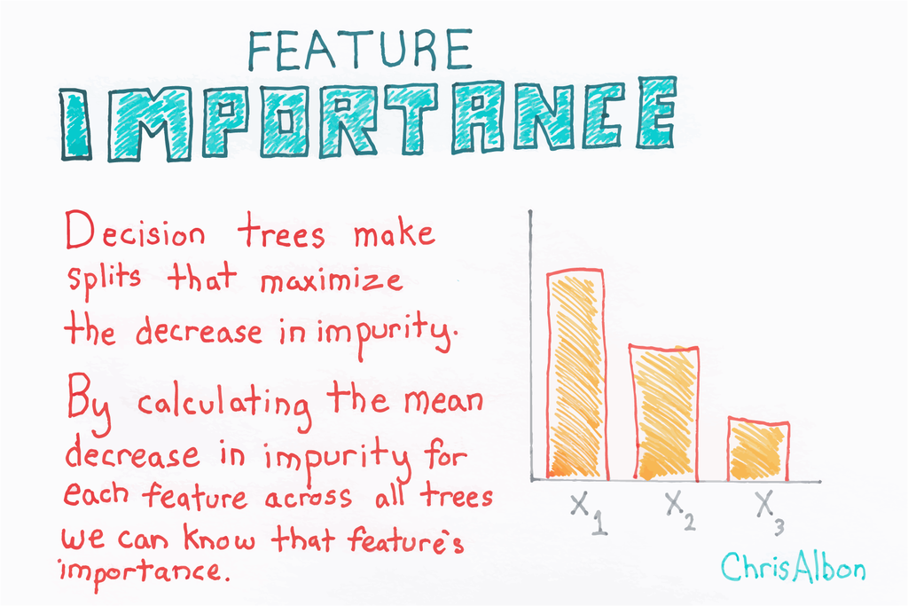

If you’ve ever created a decision tree, you’ve probably looked at measures of feature importance. In the above flashcard, impurity refers to how many times a feature was use and lead to a misclassification. Here, we’re looking at the importance of a feature, so how much it helped in the classification or prediction of an outcome.

This example will draw on the build in data `Sonar` from the `mlbench` package.

### Prepping the Environment

```r
library(caret)
library(xgboost)
library(tidyverse)
```

### Loading the data

```r
data("Sonar", package = "mlbench")
```

### Train the decision tree

```r
xgb_fit <- train(Class ~ .,
                 data = Sonar,
                 method = "xgbLinear")
```

```r
xgb_fit
```

```
## eXtreme Gradient Boosting
##
## 208 samples
##  60 predictor
##   2 classes: 'M', 'R'
##
## No pre-processing
## Resampling: Bootstrapped (25 reps)
## Summary of sample sizes: 208, 208, 208, 208, 208, 208, ...
## Resampling results across tuning parameters:
##
##   lambda  alpha  nrounds  Accuracy   Kappa
##   0e+00   0e+00   50      0.7954411  0.5856736
##   0e+00   0e+00  100      0.7955067  0.5859968
##   0e+00   0e+00  150      0.7955067  0.5859968
##   0e+00   1e-04   50      0.7931161  0.5807902
##   0e+00   1e-04  100      0.7896880  0.5736899
##   0e+00   1e-04  150      0.7896880  0.5736899
##   0e+00   1e-01   50      0.7974045  0.5899654
##   0e+00   1e-01  100      0.8007978  0.5965433
##   0e+00   1e-01  150      0.8018652  0.5987027
##   1e-04   0e+00   50      0.7936100  0.5817500
##   1e-04   0e+00  100      0.7902008  0.5746993
##   1e-04   0e+00  150      0.7902008  0.5746993
##   1e-04   1e-04   50      0.7916874  0.5777943
##   1e-04   1e-04  100      0.7883283  0.5708511
##   1e-04   1e-04  150      0.7883283  0.5708511
##   1e-04   1e-01   50      0.7974045  0.5899654
##   1e-04   1e-01  100      0.8007978  0.5965433
##   1e-04   1e-01  150      0.8018652  0.5987027
##   1e-01   0e+00   50      0.7937810  0.5824365
##   1e-01   0e+00  100      0.7958099  0.5863334
##   1e-01   0e+00  150      0.7958099  0.5863334
##   1e-01   1e-04   50      0.7953707  0.5854209
##   1e-01   1e-04  100      0.7963228  0.5873658
##   1e-01   1e-04  150      0.7963228  0.5873658
##   1e-01   1e-01   50      0.7987849  0.5923712
##   1e-01   1e-01  100      0.8034709  0.6018293
##   1e-01   1e-01  150      0.8049729  0.6047501
##
## Tuning parameter 'eta' was held constant at a value of 0.3
## Accuracy was used to select the optimal model using the largest value.
## The final values used for the model were nrounds = 150, lambda = 0.1, alpha
##  = 0.1 and eta = 0.3.
```

### Extract feature importance

Since we are using the `caret` package we can use the built in function to extract feature importance, or the function from the `xgboost` package. We will do both.

#### `caret` feature importance

```r
caret_imp <- varImp(xgb_fit)
```

```
## [13:13:23] WARNING: amalgamation/../src/learner.cc:851: Loading model from XGBoost < 1.0.0, consider saving it again for improved compatibility
```

```r
caret_imp
```

```
## xgbLinear variable importance
##
##   only 20 most important variables shown (out of 60)
##
##     Overall
## V11 100.000
## V45  26.941
## V16  24.354
## V21  21.665
## V51  18.798
## V4   18.140
## V48  14.366
## V9   12.607
## V31  12.489
## V27  12.347
## V15  11.269
## V34   9.125
## V37   8.805
## V20   8.792
## V52   8.114
## V28   7.162
## V32   5.897
## V55   4.584
## V17   4.490
## V49   4.129
```

#### `xgboost` feature importance

```r
xgb_imp <- xgb.importance(feature_names = xgb_fit$finalModel$feature_names,
               model = xgb_fit$finalModel)
```

```
## [13:13:23] WARNING: amalgamation/../src/learner.cc:851: Loading model from XGBoost < 1.0.0, consider saving it again for improved compatibility
```

```r
head(xgb_imp)
```

```
##    Feature       Gain      Cover  Frequency
## 1:     V11 0.25619824 0.12851517 0.03283582
## 2:     V45 0.06902206 0.04458378 0.03582090
## 3:     V16 0.06239349 0.04163116 0.01492537
## 4:     V21 0.05550596 0.03471532 0.02686567
## 5:     V51 0.04816044 0.04527492 0.05373134
## 6:      V4 0.04647540 0.03484923 0.03880597
```

### Plotting feature importance

#### caret

You have a few options when it comes to plotting feature importance. You can call plot on the saved object from caret as follows:

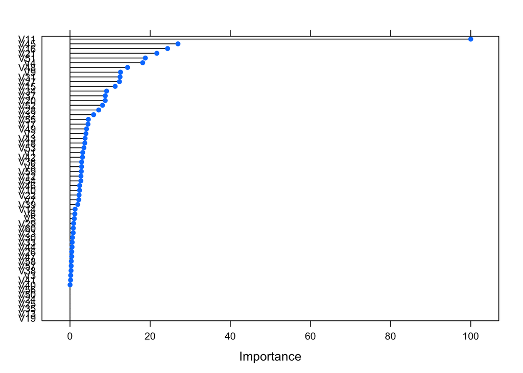

```r
plot(caret_imp)
```

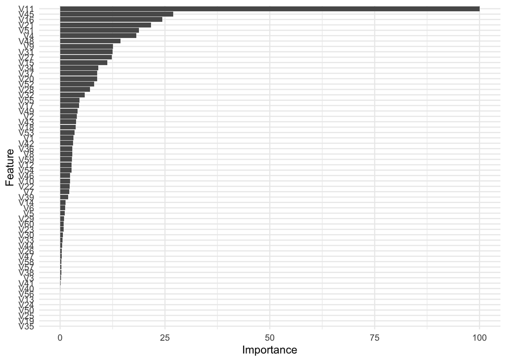

```r
ggplot(caret_imp) +
  theme_minimal()
```

#### `xgboost`

You can use the plot functionality from `xgboost`

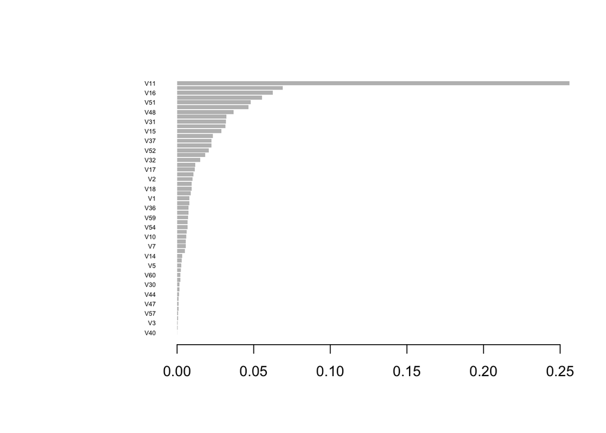

```r
xgb.plot.importance(xgb_imp)
```

Or use their ggplot feature

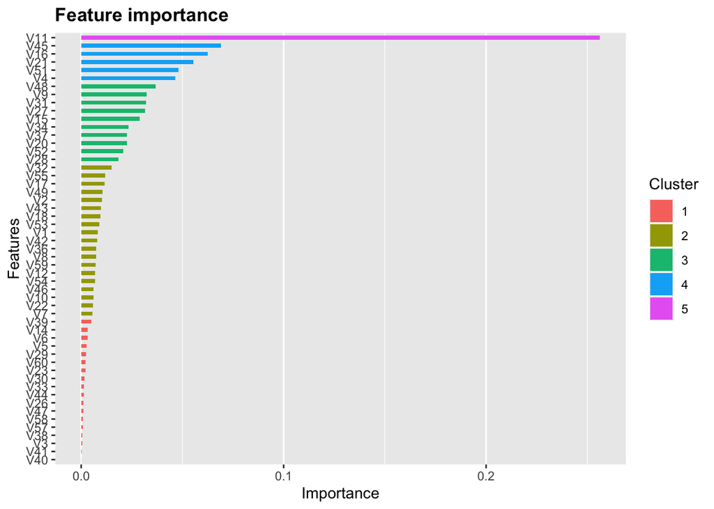

```r
xgb.ggplot.importance(xgb_imp)
```